# Part II - (Ford GoBike System Data Explanatory Visualization)

## by (Adewunmi Giwa)

## Investigation Overview

> I will be investigating the usage of Ford Go Bike. Specifically, I intend to find out when they mostly used in terms of time of day, day of week, and month of year; the average trip distance and trip duration; whether most users are subscribers or customers; and whether the findings from above depend on whether the user is a customer or subscriber.

## Dataset Overview

> This data set includes information about individual rides made in a bike-sharing system covering the greater San Francisco Bay area. I obtained links to monthly datasets from January to December, 2019 from this lnk: https://s3.amazonaws.com/baywheels-data/index.html

> I programatically downloaded the zipfiles containing the dataset for each month using os and requests libraries. Thereafter, I extracted the dataset from each file. I then merged all monthly datasets into one single csv fle.

## Hourly Bike Rides

- Highest number of trips were taken around 5pm (17:00 to 17:59)
- The least number of trips were taken between 3 and 4am

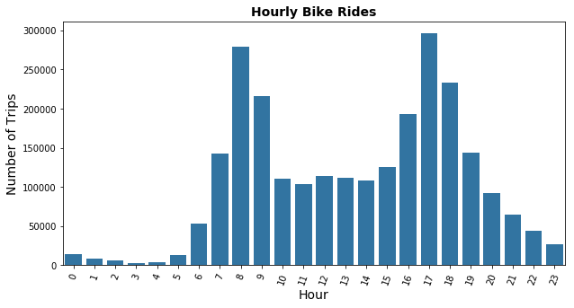

```python
#when were most trips taken in terms of time of day?
plt.figure(figsize=[10,5]);
base_color= sb.color_palette()[0]
sb.countplot(data= bike_df, x='start_hour', color= base_color);
plt.xticks(rotation= 70);
plt.xlabel('Hour',fontsize=14);
plt.ylabel('Number of Trips', fontsize=14);
plt.title('Hourly Bike Rides', fontsize=14, fontweight='bold');
```

## Daily Bike Rides

- Most bike trips were taken on a Tuesday, followed closely by a Thursday
- The least number of bike trips were taken on a Sunday

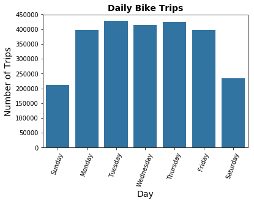

```python
#when were most trips taken in terms of day of week?
days = ['Sunday', 'Monday', 'Tuesday', 'Wednesday', 'Thursday', 'Friday', 'Saturday']
day_of_week = pd.api.types.CategoricalDtype(ordered = True, categories = days)
bike_df['start_day']= bike_df['start_day'].astype(day_of_week)

sb.countplot(data=bike_df, x='start_day', color= base_color);
plt.xticks(rotation= 70);
plt.xlabel('Day', fontsize=14);
plt.ylabel('Number of Trips', fontsize=14);
plt.title('Daily Bike Trips', fontsize=14, fontweight='bold');
```

## Monthly Bike Rides

- Most bike trips were taken in July, followed closely by March
- The least number of bike trips were taken in December

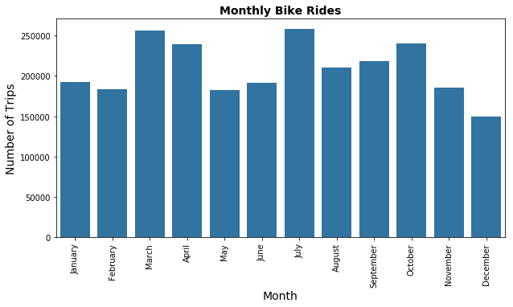

```python
#when were most trips taken in terms of month of year?
plt.figure(figsize=[10,5])
months = ['January', 'February', 'March', 'April', 'May', 'June', 'July', 'August', 'September', 'October', 'November', 'December']
months_of_year = pd.api.types.CategoricalDtype(ordered = True, categories = months)
bike_df['start_month']= bike_df['start_month'].astype(months_of_year);

sb.countplot(data= bike_df, x='start_month', color= base_color);
plt.xticks(rotation= 90);
plt.xlabel('Month', fontsize=14);
plt.ylabel('Number of Trips', fontsize=14);
plt.title('Monthly Bike Rides', fontsize=14, fontweight='bold');
```

## Distribution of Trip Duration and Distance Travelled

- Number of trips generally reduced with increasing duration
- Number of trips generally reduced with increasing distance

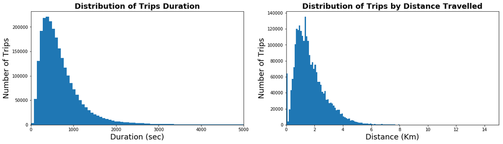

```python
#what is the distribution of trip duration
plt.figure(figsize=[20,5]);
plt.subplot(1,2,1);
bins=np.arange(0, bike_df['duration_sec'].max()+70, 70)
plt.hist(data= bike_df, x='duration_sec', color= base_color, bins=bins);
plt.xlabel('Duration (sec)', fontsize=18);
plt.ylabel('Number of Trips', fontsize=18);
plt.title('Distribution of Trips Duration', fontsize=18, fontweight='bold');
plt.xlim(0, 5000)

#what is the distribution of distance travelled
plt.subplot(1,2,2);
bins=np.arange(0, bike_df['distance_km'].max()+0.1, 0.1)
plt.hist(data= bike_df, x='distance_km', color= base_color, bins=bins);
plt.xlabel('Distance (Km)', fontsize=18);
plt.ylabel('Number of Trips', fontsize=18);
plt.title('Distribution of Trips by Distance Travelled', fontsize=18, fontweight='bold');
plt.xlim(0, 15);
```

## Distribution of Bike Rides by User Type

- 19.4% of bike rides were taken by customers, while 80.6% were taken by subscribers

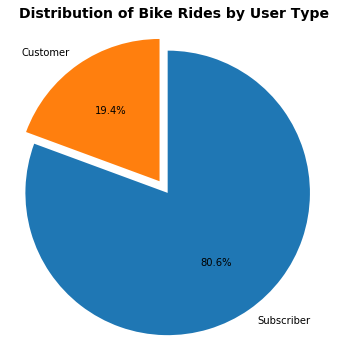

```python
#What is the distribution of bike users by user type
plt.figure(figsize=[6,6])
explode= (0.02, 0.08)
sorted_counts=bike_df['user_type'].value_counts()
plt.pie(sorted_counts, labels= sorted_counts.index, explode=explode, autopct='%1.1f%%', startangle=90,
        shadow= False, counterclock= False);
plt.axis('square');
plt.title('Distribution of Bike Rides by User Type', fontsize=14, fontweight='bold');
```

## Monthly Bike Usage per User Type

- Highest number of trips taken by subscribers was observed in March, while lowest number of trips was observed in December.
- For customers, highest number of trips was observed in December, while lowest number of trips was observed in February.

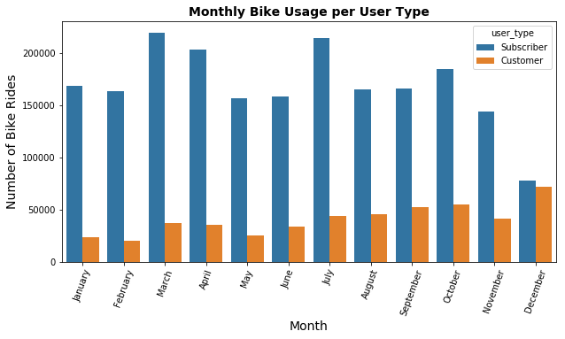

```python
#what is the distribution of monthly bike usage per user type?
plt.figure(figsize=[10,5]);
sb.countplot(data = bike_df, x = 'start_month', hue = 'user_type');
plt.xlabel('Month', fontsize=14);
plt.ylabel('Number of Bike Rides', fontsize=14);
plt.title('Monthly Bike Usage per User Type', fontsize=14, fontweight='bold');
plt.xticks(rotation=70);
```

## Daily Bike Usage per User Type

- For subscribers, most bike trips were taken on a Tuesday, and the least number of bike trips were taken on a Sunday.
- For customers, number of bike trips per day did not vary significantly, however, most bike trips were taken on a Friday.

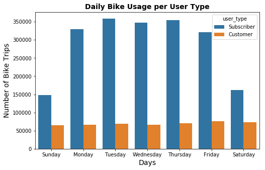

```python
#what is the distribution of daily bike usage per user type?
plt.figure(figsize=[8,5]);
sb.countplot(data = bike_df, x = 'start_day', hue = 'user_type');
plt.xlabel('Days', fontsize=14);
plt.ylabel('Number of Bike Trips', fontsize=14);
plt.title('Daily Bike Usage per User Type', fontsize=14, fontweight='bold');
```

## Trip Duration per User Type

- Subscribers generally had shorter bike trips than customers
- Customers travelled for longer periods than subscribers

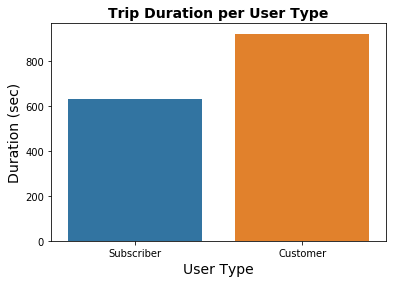

```python
#what is the distribution of trip duration per user type?
sb.barplot(data=query_df, x='user_type', y='duration_sec');
plt.xlabel('User Type',fontsize=14);
plt.ylabel('Duration (sec)',fontsize=14);
plt.title('Trip Duration per User Type', fontsize=14, fontweight='bold');
```

## Trip Distance per User Type

- Difference between average distance travelled by subscribers and customers is not significant, however, customers travelled longer distance on average than subscribers

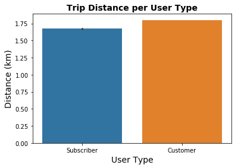

```python
#what is the distribution of trip distance per user type?
sb.barplot(data=query2_df, x='user_type', y='distance_km');
plt.xlabel('User Type',fontsize=14);
plt.ylabel('Distance (km)', fontsize=14);
plt.title('Trip Distance per User Type', fontsize=14, fontweight='bold');
```

## Average Trip Duration per Month and User Type

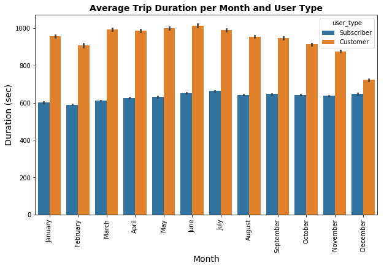

```python
#month vs duration vs user_type
plt.figure(figsize=[10,6]);
sb.barplot(data=query_df, x='start_month', y='duration_sec', hue='user_type');
plt.xticks(rotation= 90);
plt.xlabel('Month', fontsize=14);
plt.ylabel('Duration (sec)', fontsize=14);
plt.title('Average Trip Duration per Month and User Type', fontweight='bold', fontsize=14);
```

## Average Trip Duration per Day and User Type

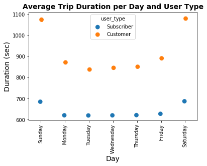

```python
#day vs duration vs user_type
sb.pointplot(data=query_df, x='start_day', y='duration_sec', hue='user_type', linestyles='', dodge= True);
plt.xticks(rotation= 90);
plt.xlabel('Day', fontsize=14);
plt.ylabel('Duration (sec)', fontsize=14);
plt.title('Average Trip Duration per Day and User Type', fontweight='bold', fontsize=14);
```

## Average Trip Duration per Hour and User Type

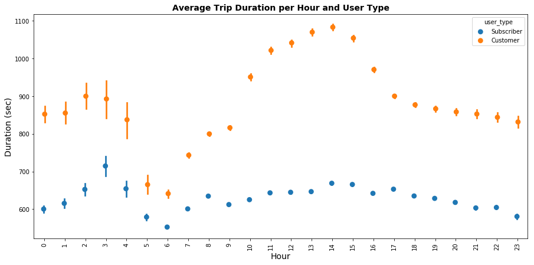

```python
#hour vs duration vs user_type
plt.figure(figsize=[15,7]);
sb.pointplot(data=query_df, x='start_hour', y='duration_sec', hue='user_type', linestyles='', dodge= True);
plt.xticks(rotation= 90);
plt.xlabel('Hour', fontsize=14);
plt.ylabel('Duration (sec)', fontsize=14);
plt.title('Average Trip Duration per Hour and User Type', fontweight='bold', fontsize=14);
```

## Average Trip Distance per Month and User Type

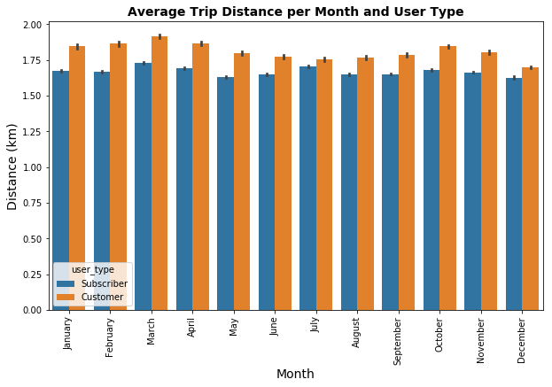

```python
#month vs distance vs user_type
plt.figure(figsize=[10,6]);
sb.barplot(data=query2_df, x='start_month', y='distance_km', hue='user_type');
plt.xticks(rotation= 90);
plt.xlabel('Month', fontsize=14);
plt.ylabel('Distance (km)', fontsize=14);
plt.title('Average Trip Distance per Month and User Type', fontweight='bold', fontsize=14);
```

## Average Trip Distance per Day and User Type

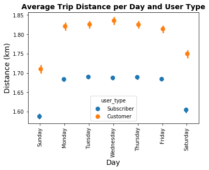

```python
#day vs distance vs user_type
sb.pointplot(data=query2_df, x='start_day', y='distance_km', hue='user_type', linestyles='', dodge= True);
plt.xticks(rotation= 90);
plt.xlabel('Day', fontsize=14);
plt.ylabel('Distance (km)', fontsize=14);
plt.title('Average Trip Distance per Day and User Type', fontweight='bold', fontsize=14);
```

## Average Trip Distance per Hour and User Type

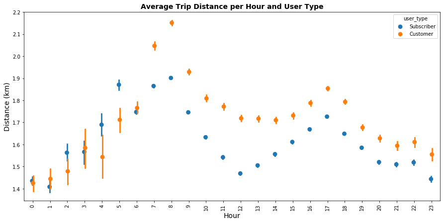

```python
#hour vs distance vs user_type
plt.figure(figsize=[15,7]);
sb.pointplot(data=query2_df, x='start_hour', y='distance_km', hue='user_type', linestyles='', dodge= True);
plt.xticks(rotation= 90);
plt.xlabel('Hour', fontsize=14);
plt.ylabel('Distance (km)', fontsize=14);
plt.title('Average Trip Distance per Hour and User Type', fontweight='bold', fontsize=14);
```